# Examen Series Temporales

Ricardo Alcañiz Frutos

14/06/2020

# Primera parte

## Apartado 1

Lectura del fichero de mobilidad de la ciudad de Nueva York.

```r
suppressPackageStartupMessages(library(descomponer))
suppressPackageStartupMessages(library(forecast))
suppressPackageStartupMessages(library(ggfortify))
suppressPackageStartupMessages(library(ggplot2))
suppressPackageStartupMessages(library(RJDemetra))
suppressPackageStartupMessages(library(tseries))
suppressPackageStartupMessages(library(zoo))


ny.mobility <- read.csv("41743097-raw_ny_D.csv")
```

Mostramos los 10 primeros y últimos registros.

```r
# 10 primeros registos
head(ny.mobility, 10)
```

```
##     X        region    mode       date  index weekend holiday
## 1   1 New York City Driving 2020-01-13 100.00   FALSE   FALSE
## 2   2 New York City Driving 2020-01-14 101.51   FALSE   FALSE
## 3   3 New York City Driving 2020-01-15 104.51   FALSE   FALSE
## 4   4 New York City Driving 2020-01-16 108.78   FALSE   FALSE
## 5   5 New York City Driving 2020-01-17 122.44   FALSE   FALSE
## 6   6 New York City Driving 2020-01-18  99.70    TRUE    TRUE
## 7   7 New York City Driving 2020-01-19  93.56    TRUE    TRUE
## 8   8 New York City Driving 2020-01-20  97.60   FALSE   FALSE
## 9   9 New York City Driving 2020-01-21  99.99   FALSE   FALSE
## 10 10 New York City Driving 2020-01-22 101.69   FALSE   FALSE
```

```r
# 10 últimos registros
tail(ny.mobility, 10)
```

```
##       X        region    mode       date index weekend holiday
## 92   92 New York City Driving 2020-04-13 36.46   FALSE   FALSE
## 93   93 New York City Driving 2020-04-14 45.90   FALSE   FALSE
## 94   94 New York City Driving 2020-04-15 46.55   FALSE   FALSE
## 95   95 New York City Driving 2020-04-16 47.23   FALSE   FALSE
## 96   96 New York City Driving 2020-04-17 51.86   FALSE   FALSE
## 97   97 New York City Driving 2020-04-18 45.56    TRUE    TRUE
## 98   98 New York City Driving 2020-04-19 42.87    TRUE    TRUE
## 99   99 New York City Driving 2020-04-20 47.49   FALSE   FALSE
## 100 100 New York City Driving 2020-04-21 44.69   FALSE   FALSE
## 101 101 New York City Driving 2020-04-22 50.27   FALSE   FALSE
```

Graficamos la serie temporal.

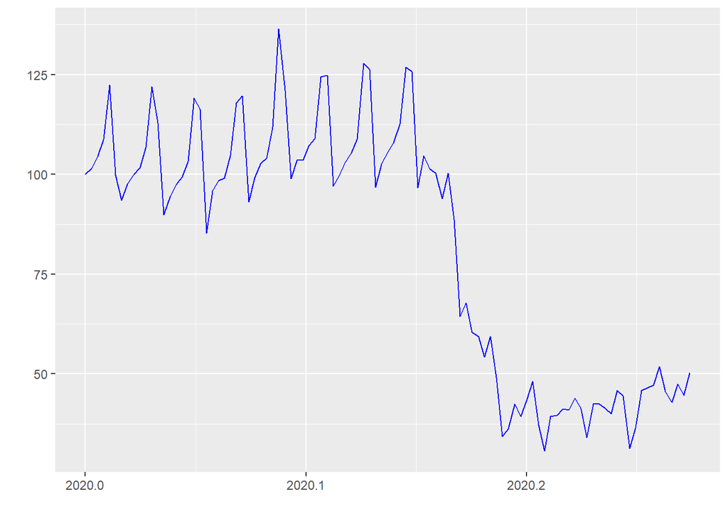

```r
# Creamos un objeto ts con los datos ya ordenados temporalmente
ts.ny.mobility <- ts(ny.mobility$index, start = c(2020, 01), frequency = 365)
autoplot(ts.ny.mobility, ts.colour = "blue")
```

La serie muestra dos tramos bien distinguidos:

```
- La primera parte de la serie muestra una tendencia poco cambiante y un comportamiento cíclico semanal, disminuyendo los fines de semana
- A medidados de Marzo, la tendencia decrece muy rápida y abruptamente hasta estabilizarse de nuevo, en el cual vuelven a aparecer de manera más clara cliclos semanales, aunque con picos más bajos, lo indica una menor movilidad semanal.
```

## Apartado 2

### Método de la bisección para la búsqueda de parámetros óptimos

Basándonos en las ideas de la demostración de Weierestrass, vamos a aplicar el método de la bisección para la búsqueda de parámetros óptimos. Por fijar ideas, supongamos que trabajamos con el modelo kernel smooth y queremos encontrar el h óptimo de ajuste a la curva de datos, evitando el sobreajuste. Para ello, partamos de una intervalo $[a,b]$ de tal manera de que el modelo para el parámetro $b$ no produzca sobreajuste, pero sí para $a$ y sea $c$ el punto intermedio de $[a, b]$. Es claro que si para $c$ el método muestra un sobreajuste, también lo hará para todo el intervalo $[a, c]$, con lo que podemos descatar éste como candidato a solución y buscar en el intervalo [c,b]. Por contra, si para c no hay sobreajuste, podemos partir del parámetro $c$ más pequeño que $b$ y, por tanto, con mejor ajuste global esperado sin que se produzca sobreajuste y plantear la problemática inicial para el intervalo $[a, c]$. Así, en un número logarítimico de pasos, estaremos cerca del ajuste óptimo. Estas ideas valen también para los splines, con el parámetro spar en R. Por lo tanto, en vez de buscar en una malla (listado, grid, etc), en este caso se puede aplicar un método más fino y así lo haremos en los siguientes apartados. La problemática del algoritmo es cómo determinar si para un parámetro $c$ dado existe sobreajuste. En caso de poder separar la muestra en validación y test, se puede considerar que se da un sobreajuste si se tiene un buen ajuste en los datos de entrenamiento, pero no así en los de test. Sin embargo, esto presupone tener un número más o menos grande de datos como para realizar esa separación, cosa que no se da aquí. Por lo tanto, el criterio para determinar si hay sobreajuste será gráfico y la decisión no será automática, sino que será del investigador. Evidentemente, esto introduce un cierto caracter subjetivo, pero aun así el método es aplicable y nos va a servir para mejorar las soluciones, partiendo de un intervalo $[a, b]$ como el descrito anteriormente.

### Método de suavizado con medias móviles

Dado que la serie muestra un crecimiento cíclico semanal a lo largo de la serie, es de esperar que un alisado con $n=7$ elimine el efecto cíclico de la serie y muestre la tendencia de una manera más clara. En este caso, no se tiene media cero o constante, por lo que el método no sirve para realizar predicciones, pero sí describe muy bien la evolución de la tendencia.

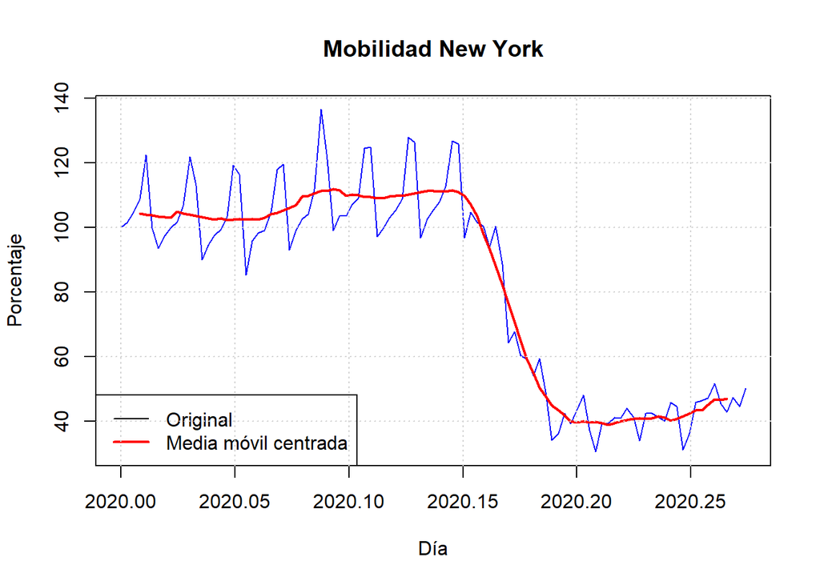

```r
# Eliminación de la variabilidad cíclica alrededor de la tendencia
plot(ts.ny.mobility, main='Mobilidad New York', xlab='Día', ylab='Porcentaje', col = "blue")
lines(rollmean(ts.ny.mobility, 7), col="red", lwd=2)
legend("bottomleft", c("Original", "Media móvil centrada"),
   lwd=c(1,2,2), col=c("black", "red"))
grid()
```

### Método de suavizado con kernel-smooth

Primeramente, se definen las funcions auxiliares para mostrar los resultados:

```r
# ts: serie temporal
# h parámetro suavizado kernel smooth
show_ksmooth_results <- function(ts, h) {
    t.kernel <- ksmooth(time(ts), ts, "normal", bandwidth = h)
    plot(ts, main='Mobilidad New York', xlab='Día', ylab='Porcentaje',col = "blue")
    lines(t.kernel, col = 2)
    legend("bottomleft", c("Original", "Kernel smooth"),
    lwd=c(1,2,2), col=c("black", "red"))
    grid()
    # Cálculo del sse
    sse <- sum((t.kernel$y - ts)^2)
    ecm <- sse / length(ts)
    print(paste("Suma errores cuadrado: ", round(sse, 2)))
    print(paste("Error cuadrático medio: ", round(ecm, 2)))
}

# ts: serie temporal
# spar parámetro suavizado smooth spline
show_smspline_results <- function(ts, spar) {
    sp <- smooth.spline(ts, spar = spar)
    plot(ts, main='Mobilidad New York', xlab='Día', ylab='Porcentaje', col = "blue")
    lines(sp, col="red", lwd=2)
    legend("bottomleft", c("Original", "Smooth spline"),
    lwd=c(1,2,2), col=c("black", "red"))
    grid()
    sse <- sum((sp$y - ts)^2)
    ecm <- sse / length(ts)
    print(paste("Suma errores cuadrado: ", round(sse, 2)))
    print(paste("Error cuadrático medio: ", round(ecm, 2)))
}
```

Puesto que el método lo vamos a implementar de una manera manual, es conveniente partir de un intervalo de longitud muy pequeña, en donde sea ya difícil intuir de manera intuitiva qué elección del parámetro realizar.

#### Paso 1

$[a, b] = [0.001, 0.03]$, $c = 0.015$

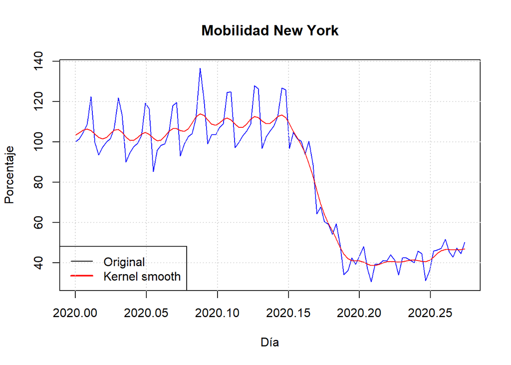

```
## [1] "Suma errores cuadrado:  5671.09"
## [1] "Error cuadrático medio:  56.15"
```

```r
h <- 0.015
show_ksmooth_results(ts.ny.mobility, h)
```

No existe sobreajuste, con lo que se hace $b=c$.

#### Paso 2

$[a, b] = [0.001, 0.015]$, $c = 0.008$

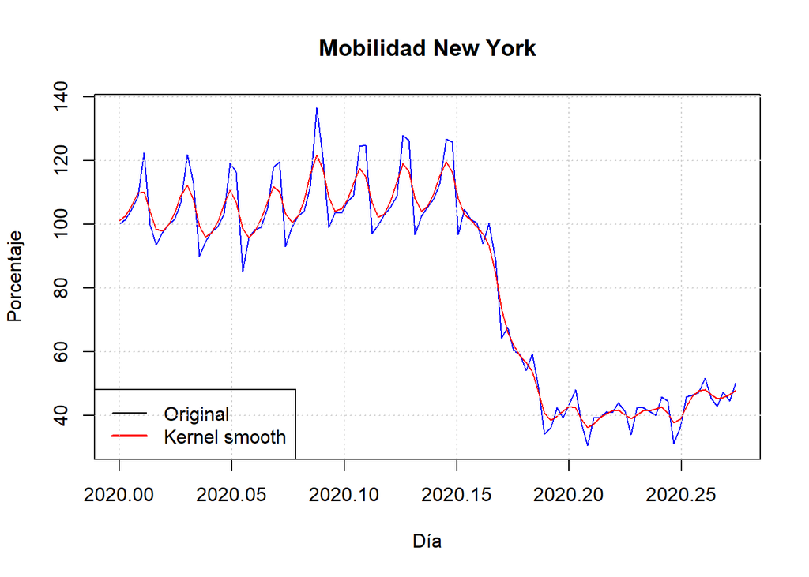

```
## [1] "Suma errores cuadrado:  2730.61"
## [1] "Error cuadrático medio:  27.04"
```

```r
h <- 0.008
show_ksmooth_results(ts.ny.mobility, h)
```

No existe sobreajuste, con lo que se hace $b=c$.

#### Paso 3

$[a, b] = [0.001, 0.008]$, $c = 0.0045$

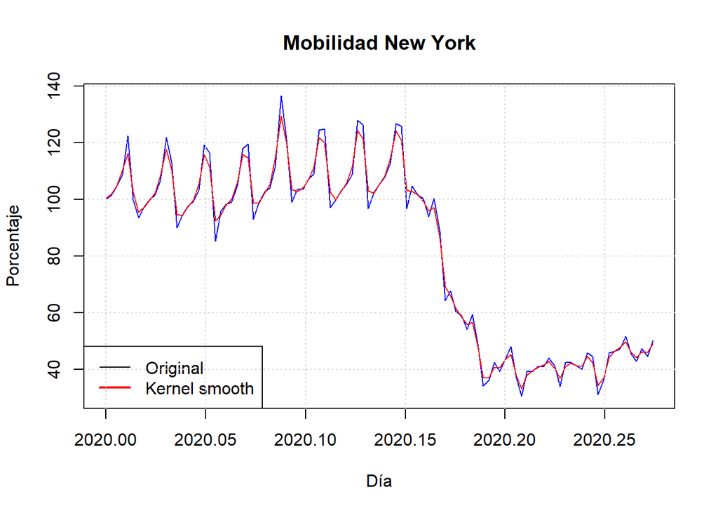

```
## [1] "Suma errores cuadrado:  700.55"
## [1] "Error cuadrático medio:  6.94"
```

```r
h <- 0.0045
show_ksmooth_results(ts.ny.mobility, h)
```

Existe sobreajuste, por lo que $c=a$.

#### Paso 4

$[a, b] = [0.0045, 0.008]$, $c = 0.0062$

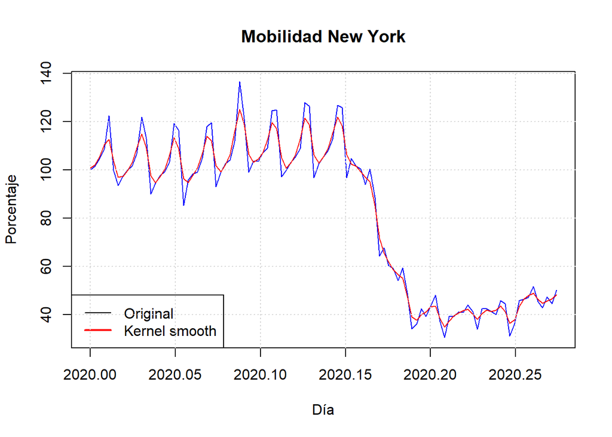

```
## [1] "Suma errores cuadrado:  1717.09"
## [1] "Error cuadrático medio:  17"
```

```r
h <- 0.0062
show_ksmooth_results(ts.ny.mobility, h)
```

Esta solución parece no presentar sobreajuste y ha mejorado notablemente la solución inicial de partida.

### Método de suavizado con smooth-spline

#### Paso 1

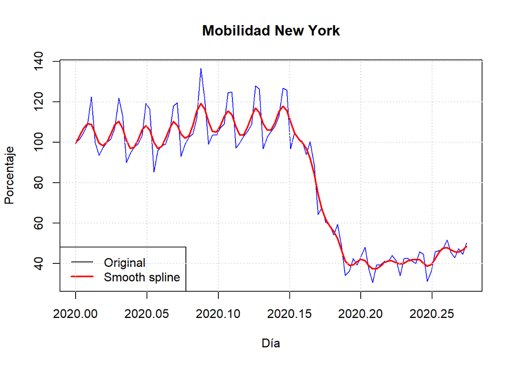

```
## [1] "Suma errores cuadrado:  3619.96"
## [1] "Error cuadrático medio:  35.84"
```

```r
spar <- 0.35
show_smspline_results(ts.ny.mobility, spar)
```

No se produce sobreajute, con lo que hacemos $b=c$.

#### Paso 2

$[a, b] = [0.1, 0.35]$, $c = 0.225$

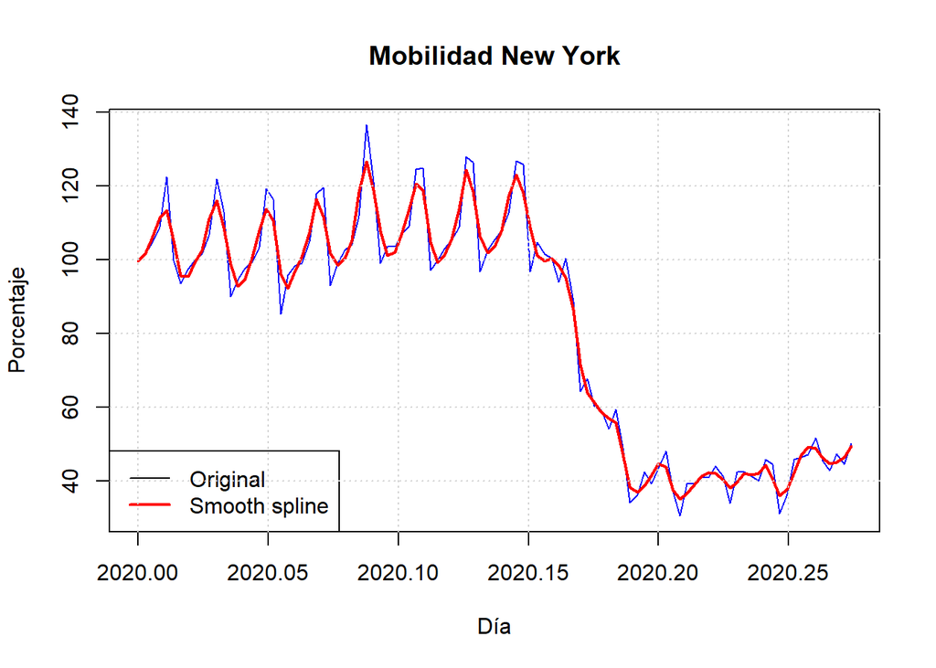

```
## [1] "Suma errores cuadrado:  1809.17"
## [1] "Error cuadrático medio:  17.91"
```

```r
spar <- 0.225
show_smspline_results(ts.ny.mobility, spar)
```

No se produce sobreajuste, por lo que tomamos $c=b$.

#### Paso 3

$[a, b] = [0.1, 0.225]$, $c = 0.1625$

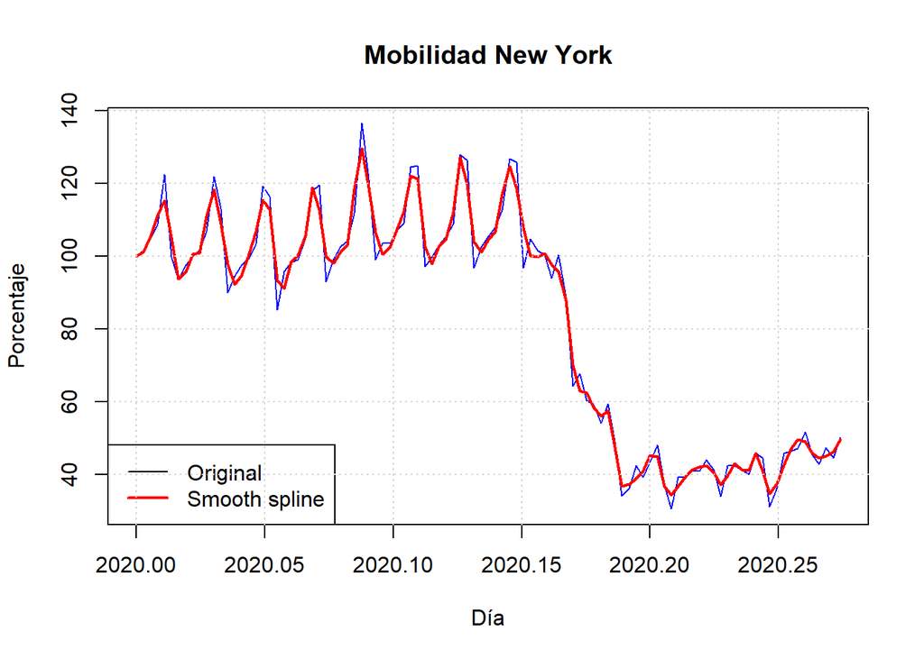

```
## [1] "Suma errores cuadrado:  1242.2"
## [1] "Error cuadrático medio:  12.3"
```

```r
spar <- 0.1625
show_smspline_results(ts.ny.mobility, spar)
```

No está totalmente claro de manera gráfica si existe sobreajuste, por lo que tomamos la solución del paso 2, que está bastante ajustada a la serie original.

### Método band spectrum

```r
library(vars)
```

[figure not shown]

```r
#indice.1 <- gdf(indice)
#ts.ny.mobility.1 <- gdf(ts.ny.mobility)
#summary(lm(ts.ny.mobility.1~indice.1))


indice=1:length(ts.ny.mobility)
# Regresión en el dominio de la frecuencia filtrando las funciones elementales de mayor frecuencia
bs.model=rdf(ts.ny.mobility,indice)
plot(ts(ts.ny.mobility,frequency = 365, start = c(2002, 1)),type="l",main="IPI.Cantabria",ylab="")
lines(ts(bs.model$datos$F,frequency = 365, start = c(2002, 1)),type="l",col=2)
legend("bottomleft", c("Original", "Regresión Band Spectrum"),
lwd=c(1,2,2), col=c("black", "red"))
grid()
```

```r
## Cálcuo de sse
sse <- sum((bs.model$datos$F - ts.ny.mobility)^2)
sse
```

```
## [1] 36360.07
```

```r
## Cálcuo de ecm
ecm <- sse / length(ts.ny.mobility)
ecm
```

```
## [1] 360.0007
```

Parece que el método está realizando una regresión adaptada a la nube de puntos por lo que, siguiendo la documentación, es probable que no se haya pasado el test de Durbin para realizar un bien filtrado.

## Análisis de los resultados y diferencias metodológicas

En vista a las métricas de evaluación, se tiene:

```
- Los métodos kernel smooht y smooth spline obtienen una solución similar en cuanto a bondad del ajuste
- El método band spectrum presenta unn mal ajuste a la serie
```

EL método de suavizado mediante medias móviles para un punto t y longitud n presenta una media centrada en dicho punto usando los n puntos vecinos más proximos, tanto mayores como menores. Se trata de una forma de eliminar la variabilidad a lo largo de la tendencia y sirve de poco para realizar predicciones, salvo en casos muy triviales.

Smooth kernel es un método de interpolación local de la función de densidad que usa una banda o ventana como parámetro fundamental para realizar el ajuste alrededor de los puntos de entrenamiento, estableciendo un peso a cada valor $X_i$.

El método smooth spline es un método de interpolación, que añade al método spline una penalización al término de error para evitar el sobreajuste. Por tanto, mientras que en el método de spline se busca la mejor de elección de la partición del dominio y la elección del grado de los splines, con smooth spline se suele trabajar con una familia fija de polinomios y nodos (orden 3 típicamente) y buscamos el mejor valor de $\lambda$ que mejor ajuste los datos.

La regresión band spectrum sigue un enfoque distinto a los anteriores. Suponiendo que una función pueda expresarse como una serie de Fourier, la idea del método es filtrar aquéllas funciones elementales (senos y cosenos) que tienen un peso muy pequeño. Así, seleccionando las series de mayor peso, conservamos la mayor parte de la varianza de la serie, eliminando la parte residual relativa a las funciones elementades con alta frecuencia y poca variabilidad. En este sentido, el método band spectrum realiza una transformación del ámbito del tiempo al ámbito de la frecuencia con la matriz de Harvey, en donse se filtran las altas frecuencias, conservando sólo aquéllas funciones elementales importantes. Una vez realizado el filtrado, se vuelve a transformar la serie al ámbito del tiempo.

# Segunda parte

## Subapartado 1

```r
# Lecturas de los datos desde fichero
emp.Cantabria <- read.csv("41743095-indust_T1995.csv")
# Creación de la serie temporal
ts.emp.Cantabria <- ts(emp.Cantabria, frequency = 4, start = c(1995, 1))
# Listado de los datos
ts.emp.Cantabria
```

```
##       Qtr1  Qtr2  Qtr3  Qtr4
## 1995 35.82 35.87 36.50 35.49
## 1996 34.71 34.05 31.72 34.80
## 1997 34.53 35.51 36.65 36.53
## 1998 37.96 37.75 36.66 39.29
## 1999 40.02 40.45 39.19 41.68
## 2000 43.16 42.02 39.55 40.44
## 2001 42.01 42.38 41.08 43.08
## 2002 44.27 44.48 41.45 43.12
## 2003 43.80 44.27 46.81 47.77
## 2004 48.99 47.57 46.80 45.84
## 2005 43.32 44.07 41.81 40.35
## 2006 42.61 40.51 45.71 46.34
## 2007 44.34 44.94 49.57 49.49
## 2008 51.81 50.82 51.02 50.54
## 2009 42.65 44.17 42.97 41.22
## 2010 41.13 38.67 38.09 37.11
## 2011 35.63 40.46 42.11 39.58
## 2012 40.19 39.78 36.20 36.26
## 2013 36.33 37.06 37.11 37.70
## 2014 37.24 36.06 36.78 37.59
## 2015 33.90 34.87 35.68 34.47
## 2016 35.50 36.72 36.93 39.24
## 2017 36.37 35.12 34.76 36.84
## 2018 36.89
```

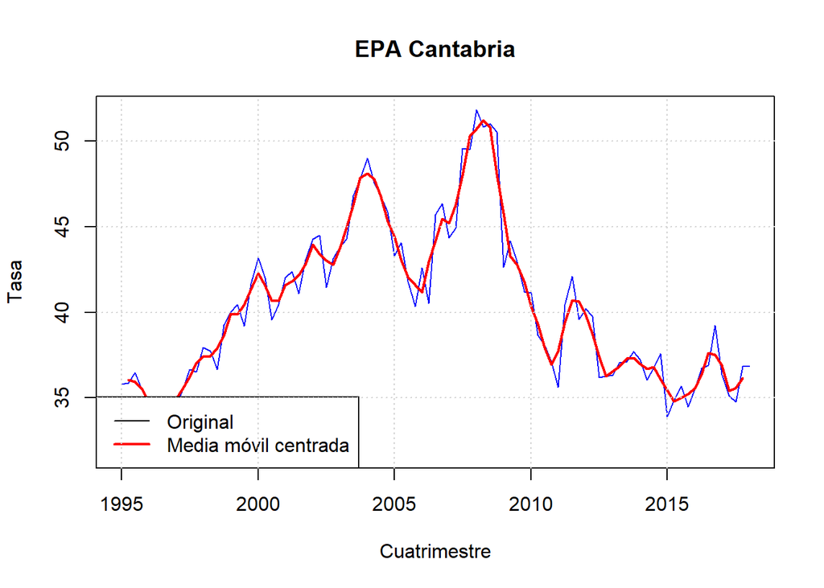

```r
# Grafico de la serie temporal
plot(ts.emp.Cantabria, main='EPA Cantabria', xlab='Cuatrimestre', ylab='Tasa', col = "blue")
# Suavizado de la serie para ver la tendencia de la serie
lines(rollmean(ts.emp.Cantabria, 3), col="red", lwd=2)
legend("bottomleft", c("Original", "Media móvil centrada"),
   lwd=c(1,2,2), col=c("black", "red"))
grid()
```

La serie presenta una tendencia de tramos crecientes y decrecientes, reflejando posiblemente las distintas crisis económicas que han afectado al paro a lo largo de la serie histórica. Alrededor de la tendencia, se pueden distinguir ciclos que reflejan un claro componente estacional ligado a la actividad económica a lo largo de toda la serie histórica.

## Subapartado 2

Usamos el modelo Tramo-Seat con la opción RSAfull. Como se indica en la documentación, las operaciones para la opción RSAFULL son:

- Transformación logarítmica de la serie (si procede)
- Detección de valores extremos
- Efectos de calendario (como festivos, por ejemplo)
- Estimación de un modelo ARIMA

```r
model.tramo.spec <- tramoseats_spec("RSAfull")
model.tramo <- tramoseats(ts.emp.Cantabria, model.tramo.spec)
print(model.tramo)
```

```
## RegARIMA
## y = regression model + arima (0, 1, 1, 0, 0, 0)
## Log-transformation: yes
## Coefficients:
##          Estimate Std. Error
## Theta(1)  -0.1631      0.104
##
##             Estimate Std. Error
## LS (I-2009)  -0.1664      0.042
##
##
## Residual standard error: 0.04243 on 89 degrees of freedom
## Log likelihood = 160.2, aic =   365 aicc = 365.3, bic(corrected for length) = -6.222
##
##
##
## Decomposition
## Model
## D :  1 - B
## MA :  1 - 0.163059 B
##
##
## SA
## D :  1 - B
## MA :  1 - 0.163059 B
##
##
## Trend
## D :  1 - B
## MA :  1 + B
## Innovation variance:  0.1751175
##
## Irregular
## Innovation variance:  0.3381766
##
##
##
## Final
## Last observed values
##             y    sa        t s         i
```

[output cut: 33 more lines]

```
##  Identifiable seasonality probably present
##
##  Residual seasonality tests
##                                       P.value
##  qs test on sa                          1.000
##  qs test on i                           1.000
##  f-test on sa (seasonal dummies)        0.818
##  f-test on i (seasonal dummies)         0.584
##  Residual seasonality (entire series)   0.778
##  Residual seasonality (last 3 years)    0.667
##  f-test on sa (td)                      0.432
##  f-test on i (td)                       0.058
##
##
## Additional output variables
```

El modelo que sigue tramo-Seats es el siguiente:

$z_t = y_t*\beta + x_t$ en donde $z_t$ es la serie original, $y_t$ es un vector de $n$ variables y modeliza el efecto de los valores atípicos, efectos de calendario (días, como los festivos, que por su naturaleza pueden afectar el comportamineto puntualmente de la variable respuesta), efecto del año bisiesto y variables definidas por el usuario. Por tanto, esta parte del modelo determina el peso que pueden tener determinados efectos puntuales en la serie. Por otro lado, $x_t$ sigue un modelo arima de la forma $\phi(B)\delta(B)x_t = \theta(B)a_t$ en donde $a_t$ es un ruido blanco Gaussiano, $\theta(B)$ el el polinomio de la parte de medias móviles del modelo ARIMA, $\delta(B)$ es la parte autorregresiva del modelo, incluyendo la parte de diferenciación y $\phi(B)$ es la parte estacional del modelo. Por tanto, el modelo descompone la serie en tres partes:

- La tendencia
- La parte estacional
- La parte irregular (modelizado en el error Gaussiano)

Los coeficientes de los polinomios pueden verse en la parte ‘Decomposition’ de los resultados arrojados por el modelo. El polinomio SA indica la modelización de la parte estacional, con lo que claramente Tramo-Seats está detectando un componente estacional en la serie. Además, el test de Kruskall-Wallis con un p-valor mayor que 0.05, no rechaza la hipótesis nula de no estabilidad, con lo que el componente estacional no es estable.

Además, realiza un prepocesado de los datos para tratar los valores faltantes y realizar, si es necesario, una transformación logarítmica de la serie, como he hecho se efectua en este caso.

Aunque no se pide en el ejercicio, también es interesante mostrar el error, que valida el modelo ya que éste sigue un ruido blanco Gaussiano y, según muestran los correlogramas, parece que el modelo recoge todo los efectos no aleatorios.

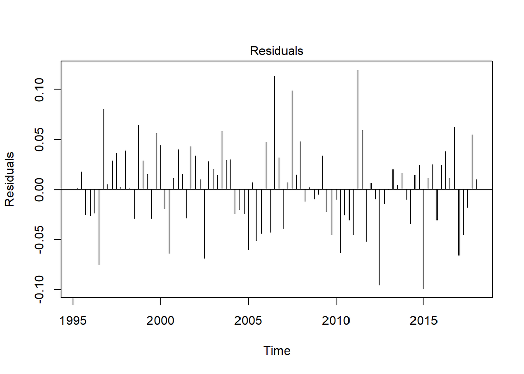

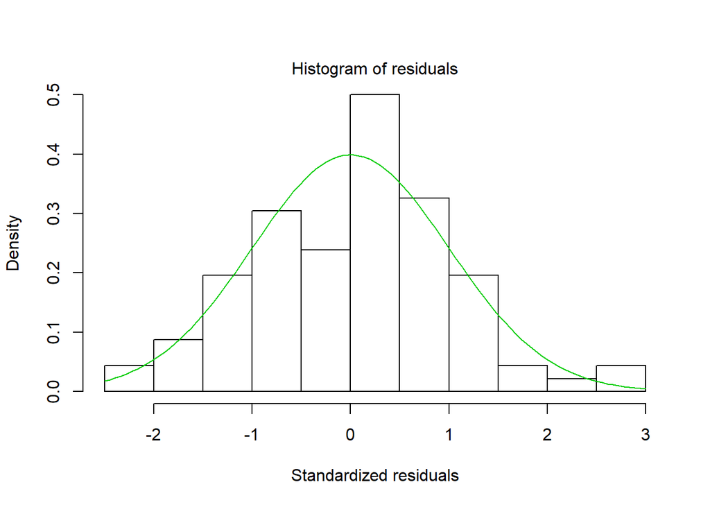

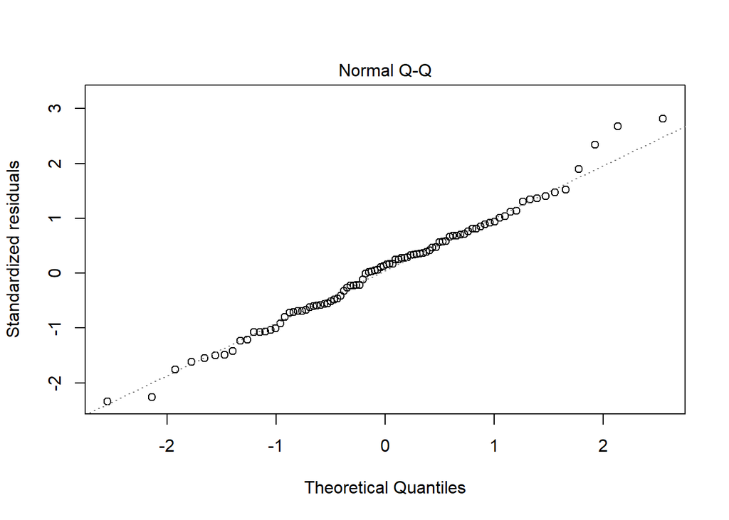

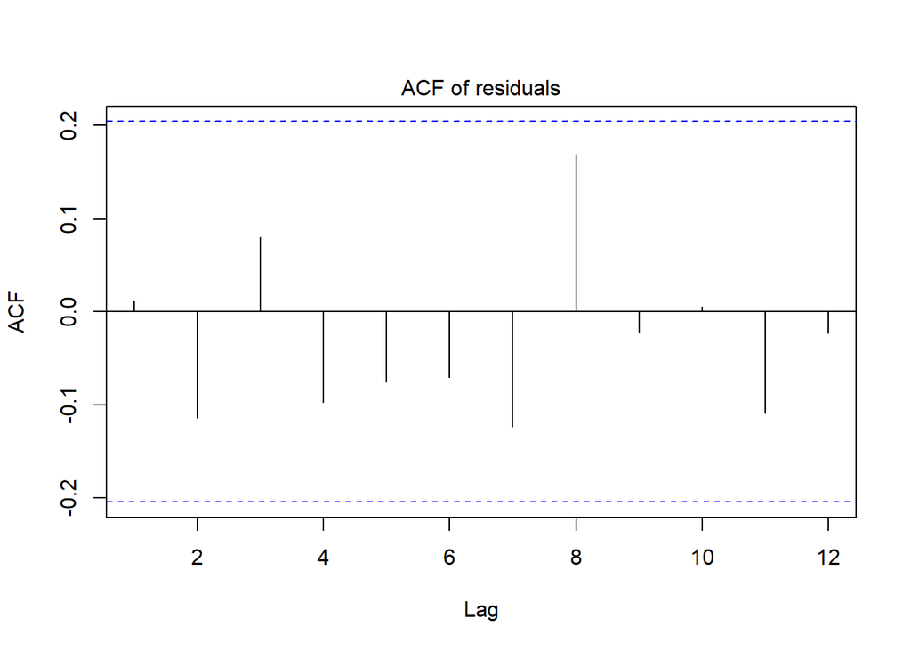

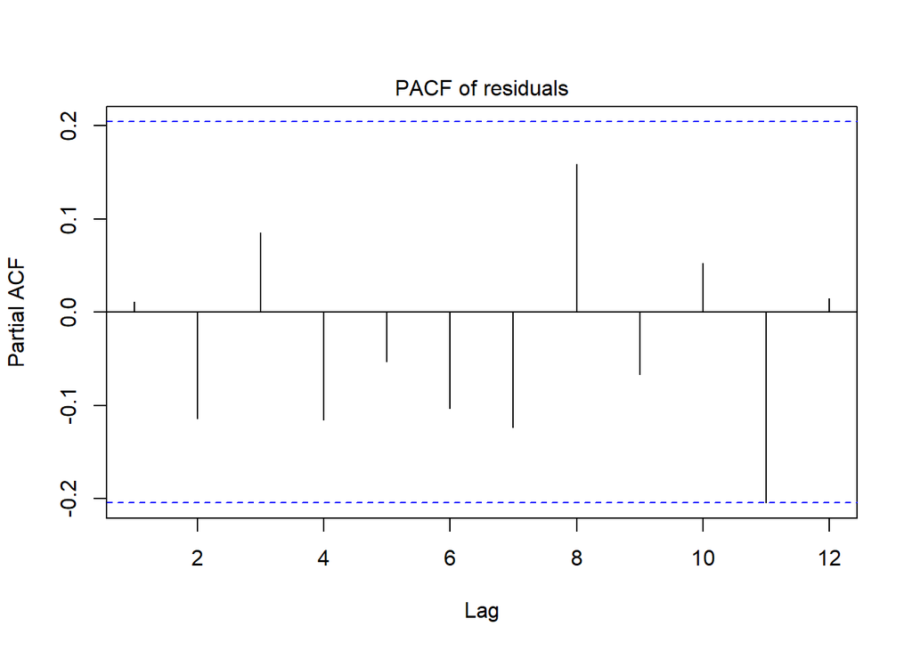

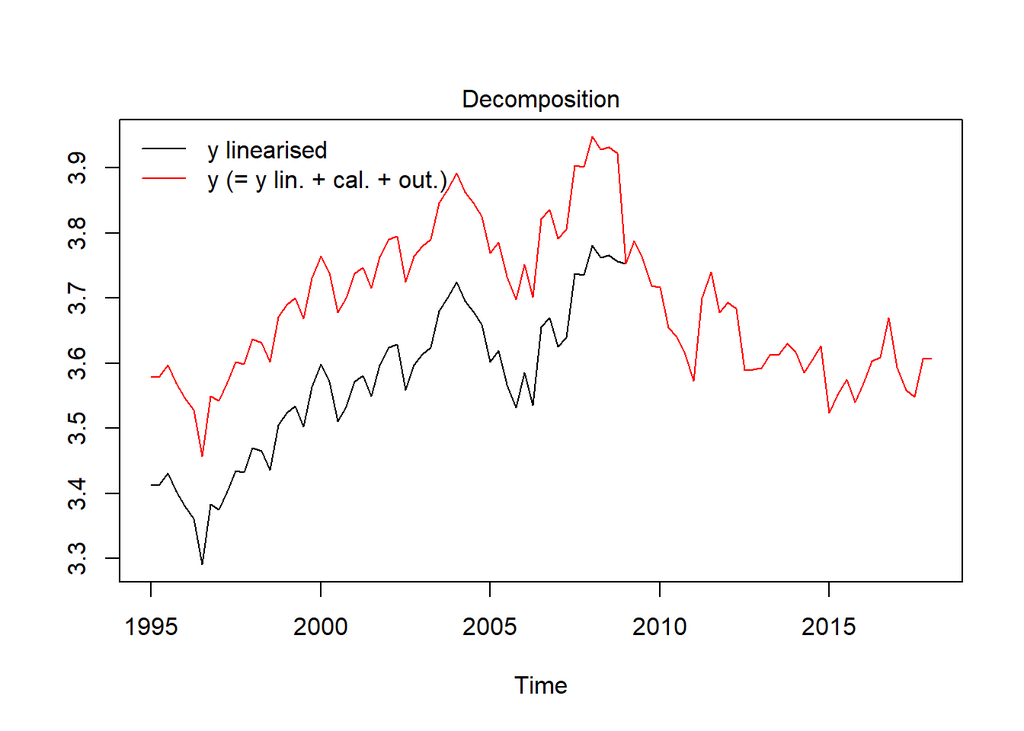

```r
plot(model.tramo$regarima)
```

## Subapartado 3

Descomposición de la serie mediante el método descompose.

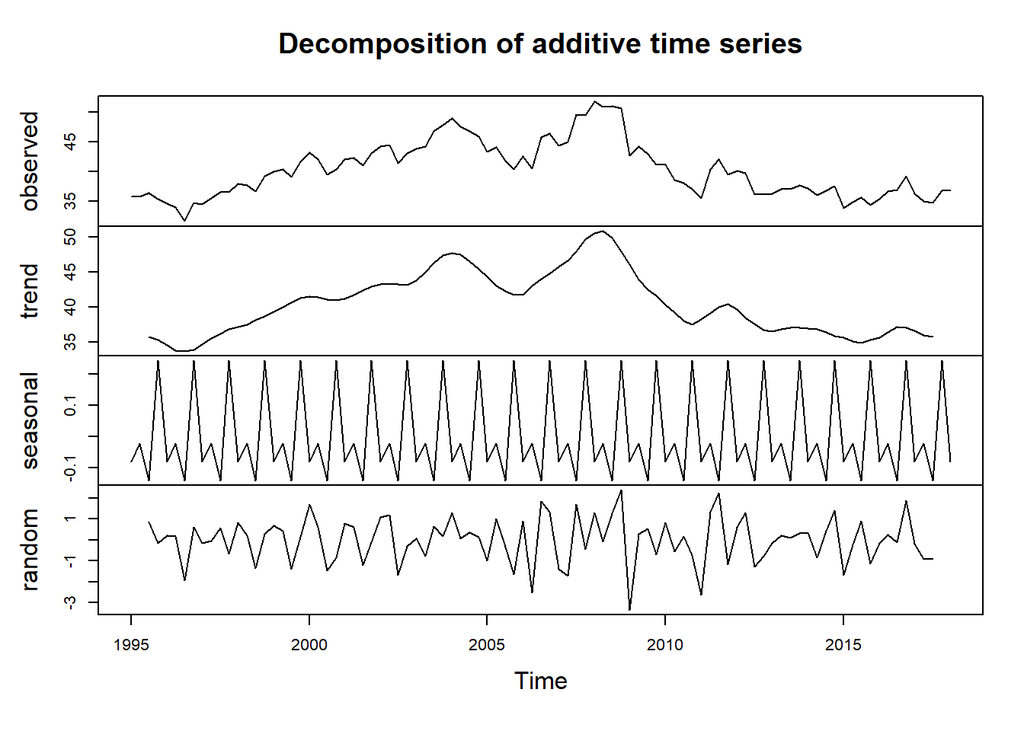

```r
# descomposoción de la serie en sus componentes tendencia, estacional y aleatorio
emp.can.decom <- decompose(ts.emp.Cantabria)
# Se muestran los componentes de la serie
plot(emp.can.decom)
```

```r
# Componente tendencia de la serie
cant.emp.tend <- emp.can.decom$trend
cant.emp.tend
```

```
##          Qtr1     Qtr2     Qtr3     Qtr4
## 1995       NA       NA 35.78125 35.41500
## 1996 34.59000 33.90625 33.79750 33.95750
## 1997 34.75625 35.58875 36.23375 36.94250
## 1998 37.22375 37.57000 38.17250 38.76750
## 1999 39.42125 40.03625 40.72750 41.31625
## 2000 41.55750 41.44750 41.14875 41.05000
## 2001 41.28625 41.80750 42.42000 42.96500
## 2002 43.27375 43.32500 43.27125 43.18625
## 2003 43.83000 45.08125 46.31125 47.37250
## 2004 47.78375 47.54125 46.59125 45.44500
## 2005 44.38375 43.07375 42.29875 41.76500
## 2006 41.80750 43.04375 44.00875 44.77875
## 2007 45.81500 46.69125 48.01875 49.68750
## 2008 50.60375 50.91625 49.90250 47.92625
## 2009 46.08875 43.91750 42.56250 41.68500
## 2010 40.38750 39.26375 38.06250 37.59875
## 2011 38.32500 39.13625 40.01500 40.50000
## 2012 39.67625 38.52250 37.62500 36.80250
## 2013 36.57625 36.87000 37.16375 37.15250
## 2014 36.98625 36.93125 36.50000 35.93375
## 2015 35.64750 35.12000 34.93000 35.36125
## 2016 35.74875 36.50125 37.20625 37.11500
## 2017 36.64375 36.07250 35.83750       NA
## 2018       NA
```

## Subapartado 4

Estudiamos las transformaciones a realizar para obtener una serie estacionaria.

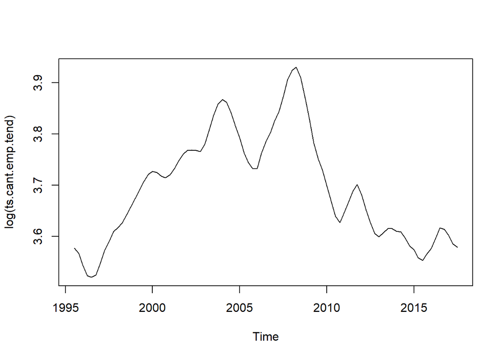

```r
# Filtrado de NAs
ts.cant.emp.tend <-  ts(cant.emp.tend[!is.na(cant.emp.tend), ], frequency = 4, start = c(1995, 3))
# Transformación logarítmica para normalizar la varianza de la serie
plot(log(ts.cant.emp.tend))
```

La transformación logarítmica sólo cambia el rango de la serie, pero se mantiene su forma. Aplicamos la operación de diferenciación.

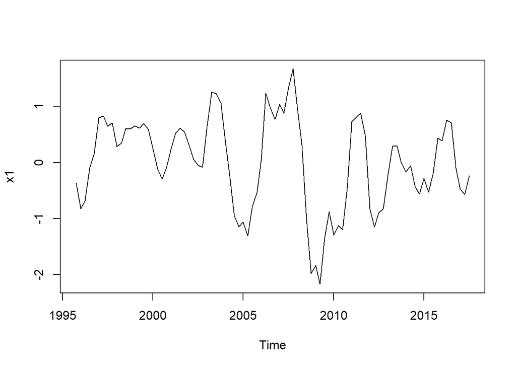

```r
x1 <- diff(ts.cant.emp.tend)
# Diferenciación de la serie para obtener una estacionaria
plot(x1)
```

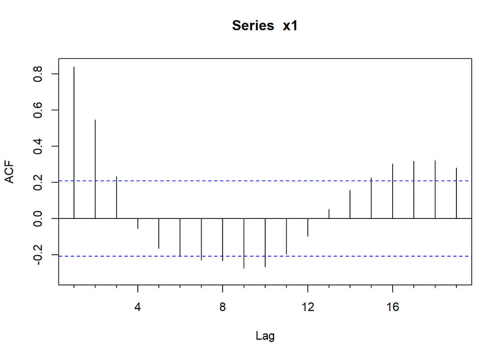

```r
Acf(x1)
```

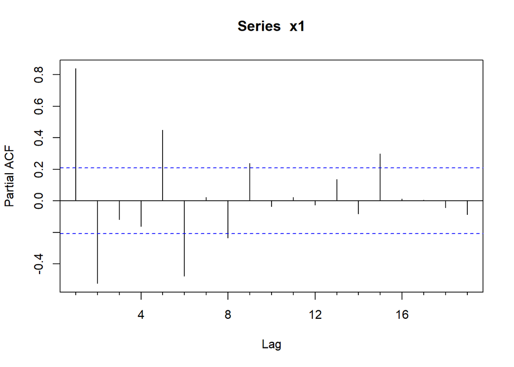

```r
Pacf(x1)
```

La función de correlación parcial indica la presencia de una componente cíclica en la serie de frecuencia 4 (como ya sabemos). Como hemos visto en el apartado anterior, la serie presenta un caracter cíclico anual, sin embargo no vamos a diferenciar de nuevo la serie ya que, por construcción, hemos eliminado la variabilidad asociada a la componente estacional (al quedarnos sólo con la tendencia) y corremos el riesgo de sobrediferenciar la serie.

En base a los correlogramas vamos a proponer 3 vectores de parámetros tanto para la parte no estacional como estacional:

- No estacional $(p,d, q) = {(2,1,0), (1,1,0), (0,1,2)}$
- Estacional $(P,D, Q) = {(0,0,2), (1,0,1), (1,0,0)}$

Por tanto, tenemos nuevo posibilidades a evaluar.